# CSCN8010 Foundations of Machine Learning Frameworks

## Practical Lab 1

### Submitted by

- Name : Sreehari Prathap
- Student ID : 8903199
- Email : sprathap3199@conestogac.on.ca

### Introduction

The Objective of this Lab is to explore the fundamentals of machine learning by training a Univariate linear regression model. Linear regression is a machine learning statistical technique used to model the relationship between variables. In Univariate regression model we are using one independent variable to predict the dependent variable.

### Goal

run a linear regression between the median house value (dependent variable) and each of the following independent variables.

- median income
- population
- number of households

### Data Exploration

We are using the [California Housing Prices](https://www.kaggle.com/datasets/camnugent/california-housing-prices) Dataset from [Kaggle](https://www.kaggle.com/). The data contains information from the 1990 California census. It provides an accessible introductory dataset for learning about the basics of machine learning. The data pertains to the houses found in a given California district and some summary stats about them based on the 1990 census data. The columns are as follows:

1. **longitude** : A measure of how far west a house is; a higher value is farther west
2. **latitude** : A measure of how far north a house is; a higher value is farther north
3. **housingMedianAge** : Median age of a house within a block; a lower number is a newer building
4. **totalRooms** : Total number of rooms within a block
5. **totalBedrooms** : Total number of bedrooms within a block
6. **population** : Total number of people residing within a block
7. **households** : Total number of households, a group of people residing within a home unit, for a block
8. **medianIncome** : Median income for households within a block of houses (measured in tens of thousands of US Dollars)
9. **medianHouseValue** : Median house value for households within a block (measured in US Dollars)
10. **oceanProximity** : Location of the house w.r.t ocean/sea

```python
import pandas as pd

df = pd.read_csv('./housing.csv')
print(df.head())
```

```
   longitude  latitude  housing_median_age  total_rooms  total_bedrooms  \
0    -122.23     37.88                41.0        880.0           129.0
1    -122.22     37.86                21.0       7099.0          1106.0
2    -122.24     37.85                52.0       1467.0           190.0
3    -122.25     37.85                52.0       1274.0           235.0
4    -122.25     37.85                52.0       1627.0           280.0

   population  households  median_income  median_house_value ocean_proximity
0       322.0       126.0         8.3252            452600.0        NEAR BAY
1      2401.0      1138.0         8.3014            358500.0        NEAR BAY
2       496.0       177.0         7.2574            352100.0        NEAR BAY
3       558.0       219.0         5.6431            341300.0        NEAR BAY
4       565.0       259.0         3.8462            342200.0        NEAR BAY
```

```python
# Explore statistics using Pandas `describe` function
df[['median_house_value', 'median_income', 'population', 'households']].describe()
```

|  | median_house_value | median_income | population | households |
| --- | --- | --- | --- | --- |
| count | 20640.000000 | 20640.000000 | 20640.000000 | 20640.000000 |
| mean | 206855.816909 | 3.870671 | 1425.476744 | 499.539680 |
| std | 115395.615874 | 1.899822 | 1132.462122 | 382.329753 |
| min | 14999.000000 | 0.499900 | 3.000000 | 1.000000 |
| 25% | 119600.000000 | 2.563400 | 787.000000 | 280.000000 |
| 50% | 179700.000000 | 3.534800 | 1166.000000 | 409.000000 |
| 75% | 264725.000000 | 4.743250 | 1725.000000 | 605.000000 |
| max | 500001.000000 | 15.000100 | 35682.000000 | 6082.000000 |

```python
# Create three Seaborn scatter plots of median house value vs. median income, population and number of households.
# There should be one scatter plot per each independent variable. Add a title to each graph (using Seaborn).
# Provide textual interpretation of the graphs, and insights specific to the linear regression you are going to conduct next.

# Import seaborn and matplotlib for plotting
import seaborn as sns
import matplotlib.pyplot as plt
```

### Scatter plot : median_house_value vs median_income

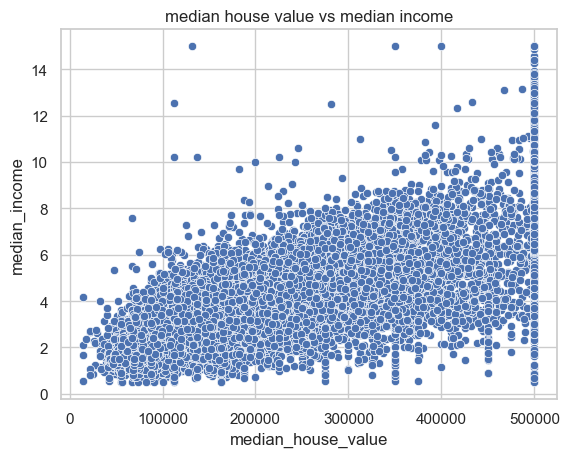

```python
# Scatter plot of median income vs median house value
sns.scatterplot(x='median_house_value', y='median_income', data=df)
# displaying the title
plt.title("median house value vs median income")
plt.show()
```

The scatter plot shows a relationship between median house vales and median income, we can see that as the median income of house hold block increases the median house vales also shows a small positive trends. The data ranges from 0 to 500000 dollars. There are some outliers in the data where people with high median_income purchased houses with low median_house_value and vice versa. But a general trend shows that as the median_income increases the median_house_value also increases slightly.

### Insights for Linear Regression

- Positive Correlation between median_income and median_house_value : As the median_income increases the median_house_value also increases.
- Outliers : There are some outliers in the data where people with high median_income purchased houses with low median_house_value and vice versa.
- Moderate fit : Even though theres a positive correlation between median_income and median_house_value, the data points are scattered and hence the fit is moderate.

### Scatter plot : median_house_value vs population

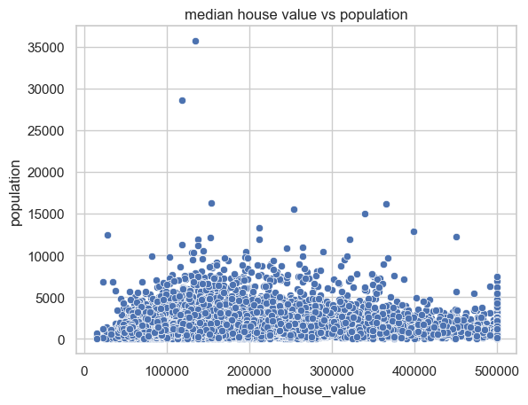

```python
# Scatter plot of median income vs median house value
sns.scatterplot(x='median_house_value', y='population', data=df)
# displaying the title
plt.title("median house value vs population")
plt.show()
```

The scatter plot shows a relationship between median house vales and population within a block. We cannot see a linear trend between the variables as we can see population generally lies between the range 0 to 5000 irrespective of the median_house_value. There are some outliers here as well where the population is high and can see some values in ranges 25000 to 35000. But the general trend shows that the population does not have a linear relationship with median_house_value.

### Insights for Linear Regression

- Weak Correlation between population and median_house_value : Theres no linear trend between population and median_house_value.
- Outliers : There are some outliers in the data where the population is high and can see some values in ranges 25000 to 35000.
- Poor fit : As theres no linear trend between population and median_house_value, the fit can be poor.

### Scatter plot : median_house_value vs households

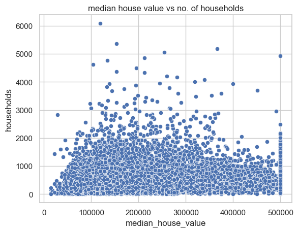

```python
# Scatter plot of median income vs median house value
sns.scatterplot(x='median_house_value', y='households', data=df)
# displaying the title
plt.title("median house value vs no. of households")
plt.show()
```

The scatter plot shows a relationship between median house vales and number of households within a block. Although we can see some outliers in this plot, the general trend shows the number of households remain mostly spread across ranges 0 to 1000. Also we can see a condensed data spread across median house values 100000 to 300000. The Plot shows a similar trend to the median_house_value vs population plot where the number of households does not have a linear relationship with median_house_value.

### Insights for Linear Regression

- Weak Correlation : We cannot see a linear trend between the households and median_house_value.
- Outliers : There are some outliers in the data where the number of households is high and median house values are in range 100000 to 300000.
- Poor fit : As theres not much of a linear trend between households and median_house_value, the fit can be poor.

### Variable Analysis

- **Independent Variables** : median_income, population, households
- **Dependent Variable** : median_house_value

#### median_house_value

This variable represents the median house value of households in a particular block. The general range of values is between 0 to 500000 dollars. The data is showing a more dense spread between 100000 to 300000 dollars.

#### median_income

This variable represents the median income of households in a particular block. The general range of values is between 0 to 15. The data is showing a more dense spread between 1 to 10. It shows a positive correlation with median_house_value and shows an increasing trend as the median_income increases.

#### population

This variable represents the total number of people residing within a block. The general range of values is between 0 to 35000. The data is showing a more dense spread between 0 to 5000. It does not show a linear trend with median_house_value. And can see some outliers where the population is high.

#### households

This variable represents the total number of households within a block. The general range of values is between 0 to 6000. The data is showing a more dense spread between 0 to 1000. It does not show a linear trend with median_house_value. And can see some outliers where the number of households is high.

### **Model 1** : median house value vs median income

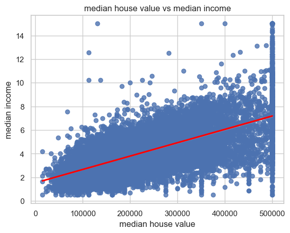

```python
# 1. Median House Value vs. Median Income
sns.regplot(x='median_house_value', y='median_income', data=df, line_kws={"color": "red"})
plt.title('median house value vs median income')
plt.xlabel('median house value')
plt.ylabel('median income')
plt.show()
```

### **Model 2** : median house value vs population

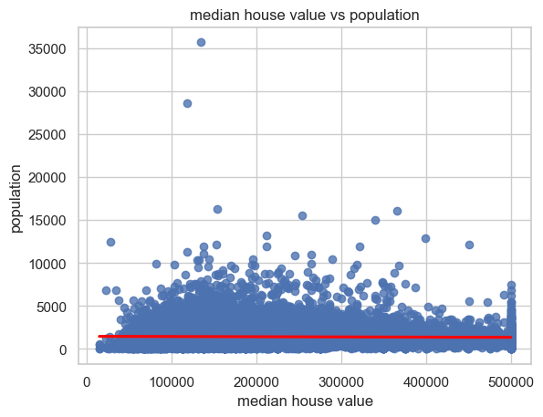

```python
# 2. median house value vs population
sns.regplot(x='median_house_value', y='population', data=df, line_kws={"color": "red"})
plt.title('median house value vs population')
plt.xlabel('median house value')
plt.ylabel('population')
plt.show()
```

### **Model 3** : median house value vs no. of household

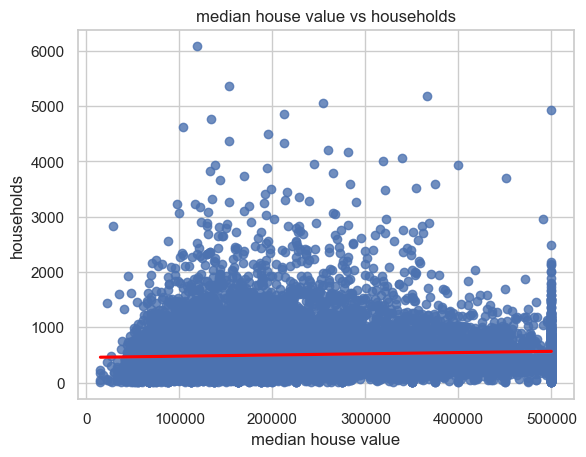

```python
# 3. median house value vs no. of households
sns.regplot(x='median_house_value', y='households', data=df, line_kws={"color": "red"})
plt.title('median house value vs households')
plt.xlabel('median house value')
plt.ylabel('households')
plt.show()
```

### Regression Analysis

```python
from sklearn.metrics import mean_squared_error, mean_absolute_error
from tabulate import tabulate

def calculate_metrices(x,y):
    model = LinearRegression()
    model.fit(x.values.reshape(-1, 1),y)

    intercept = model.intercept_
    slope = model.coef_[0]

    y_pred = model.predict(x.values.reshape(-1, 1))
    mse = mean_squared_error(y, y_pred)
    mae = mean_absolute_error(y, y_pred)

    return intercept, slope, mse, mae, y_pred

# 1. median house value vs median income
intercept1, slope1, mse1, mae1, predictions1 = calculate_metrices(df['median_house_value'], df['median_income'])

# 2. median house value vs population
intercept2, slope2, mse2, mae2, predictions2 = calculate_metrices(df['median_house_value'], df['population'])

# 3. median house value vs no. of households
intercept3, slope3, mse3, mae3, predictions3 = calculate_metrices(df['median_house_value'], df['households'])

regression_table = pd.DataFrame({
    'independent variable': ['median_income', 'population', 'households'],
    'intercept': [intercept1, intercept2, intercept3],
    'slope': [slope1, slope2, slope3],
    'mean squared error': [mse1, mse2, mse3],
    'mean absolute error': [mae1, mae2, mae3]
})

print(tabulate(regression_table, headers='keys', tablefmt='pretty'))
```

```
+---+----------------------+--------------------+------------------------+--------------------+---------------------+
|   | independent variable |     intercept      |         slope          | mean squared error | mean absolute error |
+---+----------------------+--------------------+------------------------+--------------------+---------------------+
| 0 |    median_income     | 1.5273748109684964 | 1.1328161938855743e-05 | 1.9004057684484423 | 1.0103992829873039  |
| 1 |      population      | 1475.5162923505427 | -0.0002419054436672198 | 1281629.1221874184 |  713.6590159877113  |
| 2 |      households      | 454.41399286280625 | 0.00021815043949004425 | 145535.27807645506 | 246.38124443730393  |
+---+----------------------+--------------------+------------------------+--------------------+---------------------+
```

### Regression Analysis Plots with line parameters

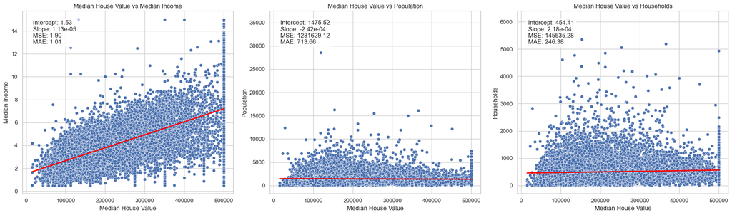

```python
# setting figure size
plt.figure(figsize=(20, 6))

# 1. median house value vs median income
# create subplots
plt.subplot(1, 3, 1)
sns.scatterplot(x=df['median_house_value'], y=df['median_income'])
# plot regression line
sns.regplot(x=df['median_house_value'], y=df['median_income'], scatter=False, color='red', ci=None)
plt.title('Median House Value vs Median Income')
# set x-axis label
plt.xlabel('Median House Value')
# set y-axis label
plt.ylabel('Median Income')
# display metrics in text box
plt.text(0.05, 0.95, f'Intercept: {intercept1:.2f}\nSlope: {slope1:.2e}\nMSE: {mse1:.2f}\nMAE: {mae1:.2f}',
         transform=plt.gca().transAxes, fontsize=12, verticalalignment='top', bbox=dict(boxstyle='round', facecolor='white', alpha=0.8))

# 2. median house value vs population
plt.subplot(1, 3, 2)
sns.scatterplot(x=df['median_house_value'], y=df['population'])
sns.regplot(x=df['median_house_value'], y=df['population'], scatter=False, color='red', ci=None)
plt.title('Median House Value vs Population')
plt.xlabel('Median House Value')
plt.ylabel('Population')
plt.text(0.05, 0.95, f'Intercept: {intercept2:.2f}\nSlope: {slope2:.2e}\nMSE: {mse2:.2f}\nMAE: {mae2:.2f}',
         transform=plt.gca().transAxes, fontsize=12, verticalalignment='top', bbox=dict(boxstyle='round', facecolor='white', alpha=0.8))

# 3. median house value vs households
plt.subplot(1, 3, 3)
sns.scatterplot(x=df['median_house_value'], y=df['households'])
sns.regplot(x=df['median_house_value'], y=df['households'], scatter=False, color='red', ci=None)
plt.title('Median House Value vs Households')
plt.xlabel('Median House Value')
plt.ylabel('Households')
plt.text(0.05, 0.95, f'Intercept: {intercept3:.2f}\nSlope: {slope3:.2e}\nMSE: {mse3:.2f}\nMAE: {mae3:.2f}',
         transform=plt.gca().transAxes, fontsize=12, verticalalignment='top', bbox=dict(boxstyle='round', facecolor='white', alpha=0.8))

plt.tight_layout()
plt.show()
```

### Summary

Based on the applications and research done on the dataset, we can understand that the median house value vs median income has a moderate fit with a positive correlation. The other two models median house value vs population and median house value vs households have a poor fit with weak correlation. The conclusions we can draw from the analysis are as follows: